# River Nile flow

Manuel Hernandez Zemljic

```r
library(forecast)
```

## Introduction

The this report aims to present an ARIMA model trained to predict the flow of the River. The training data is loaded directly from the R package ‘datasets’ and involves measurements of the annual flow of the River Nile at Aswan between 1871 and 1970 in 10^8 m^3. Visualization on the R package of the time series, autocorrelation function, and partial autocorrelation function are used for the diagnosis of the stationary of the data. The R package ‘forecast’ is used to estimate the parameters of the model.

For practicality, I load the data in the variable nile, and then I graph the time series, the acf, pacf reports that are the start point of the analysis.

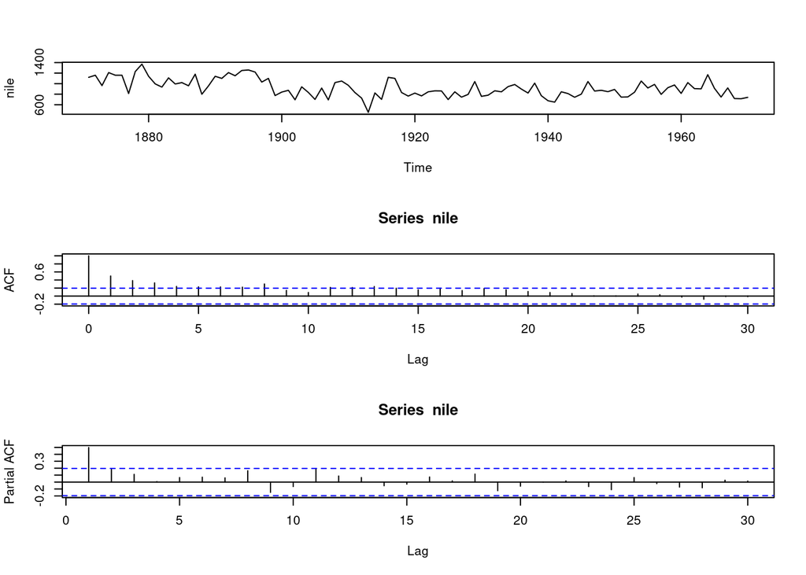

Fig. 1 Nile river time series, acf and pacf

```r
nile=Nile
par(mfrow=c(3,1))
ts.plot(nile)
acf(nile, lag.max = 30)
pacf(nile, lag.max = 30)
```

```r
nile.diff = diff(nile)
```

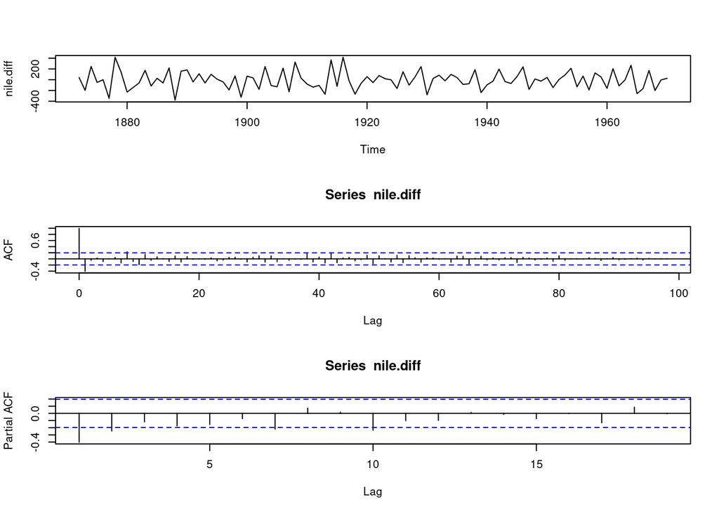

Fig. 2

```r
par(mfrow=c(3,1))
ts.plot(nile.diff)
acf(nile.diff, lag.max = 100)
pacf(nile.diff)
```

The first spike of the acf tells me there is an MA(1) in the series. One big spike in the pacf means there is an ar(1), although the second spike is very small, I am going to evaluate its inclusion as an AR(2) component.

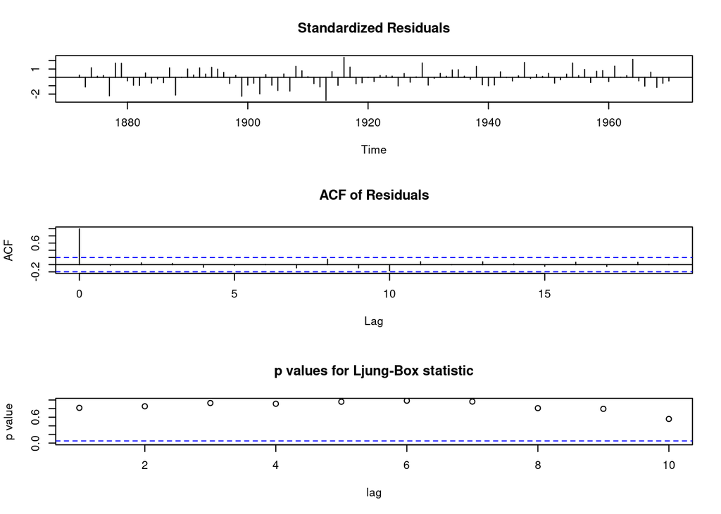

Fig. 4

```r
fit = arima(nile.diff, order = c(1,0,1))
tsdiag(fit)
```

This graph of the differenced data is telling me that an ARIMA(1,1,1) will be a good fit as all the p values are over 0.05. I am going to study the data-set using the function auto.arima from the forecast package,

```r
auto.arima(nile, ic = "aicc")
```

```
## Series: nile
## ARIMA(1,1,1)
##
## Coefficients:
##          ar1      ma1
##       0.2544  -0.8741
## s.e.  0.1194   0.0605
##
## sigma^2 estimated as 20177:  log likelihood=-630.63
## AIC=1267.25   AICc=1267.51   BIC=1275.04
```

```r
auto.arima(nile, ic = "aic")
```

```
## Series: nile
## ARIMA(1,1,1)
##
## Coefficients:
##          ar1      ma1
##       0.2544  -0.8741
## s.e.  0.1194   0.0605
##
## sigma^2 estimated as 20177:  log likelihood=-630.63
## AIC=1267.25   AICc=1267.51   BIC=1275.04
```

```r
auto.arima(nile, ic = "bic")
```

```
## Series: nile
## ARIMA(0,1,1)
##
## Coefficients:
##           ma1
##       -0.7329
## s.e.   0.1143
##
## sigma^2 estimated as 20810:  log likelihood=-632.55
## AIC=1269.09   AICc=1269.22   BIC=1274.28
```

This R output is giving me another model to analyze, an ARIMA(0,1,1). My previus analysis make me thing on four potential models that could fit the data: ARIMA(1,0,1), ARIMA(1,1,1), ARIMA(2,1,1) and ARIMA(0,1,1).

```r
fit101 = arima(nile, order = c(1,0,1))
fit101
```

```
##
## Call:
## arima(x = nile, order = c(1, 0, 1))
##
## Coefficients:
##          ar1      ma1  intercept
##       0.8611  -0.5177   920.5567
## s.e.  0.1067   0.1908    46.6736
##
## sigma^2 estimated as 19892:  log likelihood = -637.04,  aic = 1282.08
```

[output not shown]

```r
fit111 = arima(nile, order = c(1,1,1))
fit111
```

```
##
## Call:
## arima(x = nile, order = c(1, 1, 1))
##
## Coefficients:
##          ar1      ma1
##       0.2544  -0.8741
## s.e.  0.1194   0.0605
##
## sigma^2 estimated as 19769:  log likelihood = -630.63,  aic = 1267.25
```

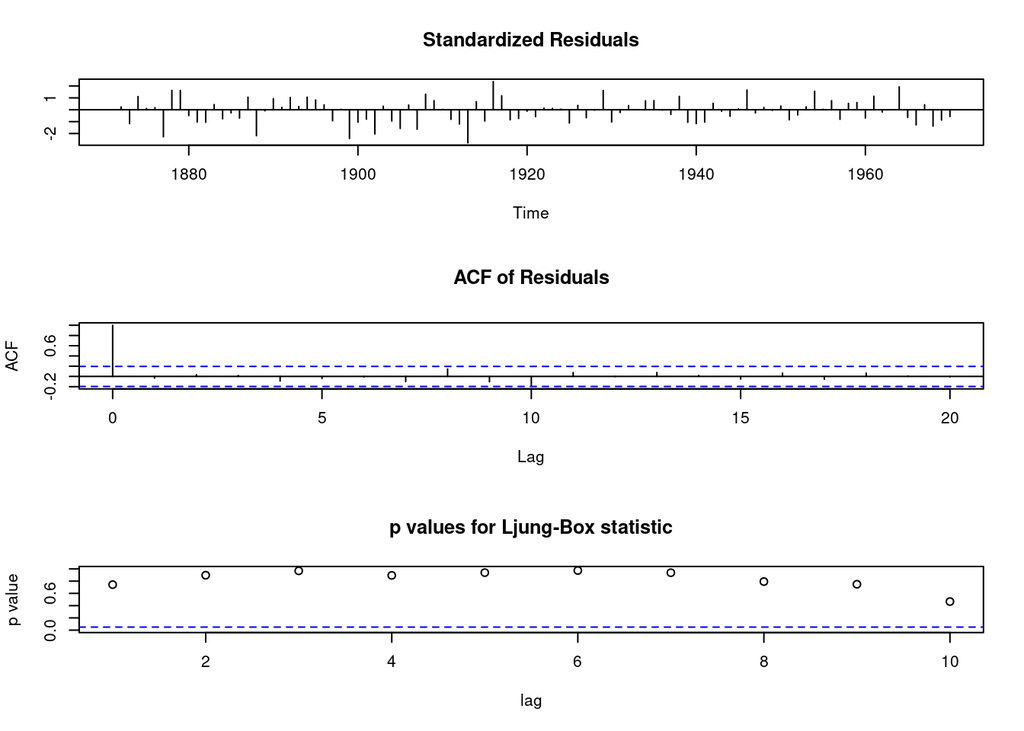

Fig. 6

```r
tsdiag(fit111)
```

```r
fit211 = arima(nile, order = c(2,1,1))
fit211
```

```
##
## Call:
## arima(x = nile, order = c(2, 1, 1))
##
## Coefficients:
##          ar1     ar2      ma1
##       0.2566  0.0664  -0.8897
## s.e.  0.1164  0.1110   0.0590
##
## sigma^2 estimated as 19700:  log likelihood = -630.45,  aic = 1268.9
```

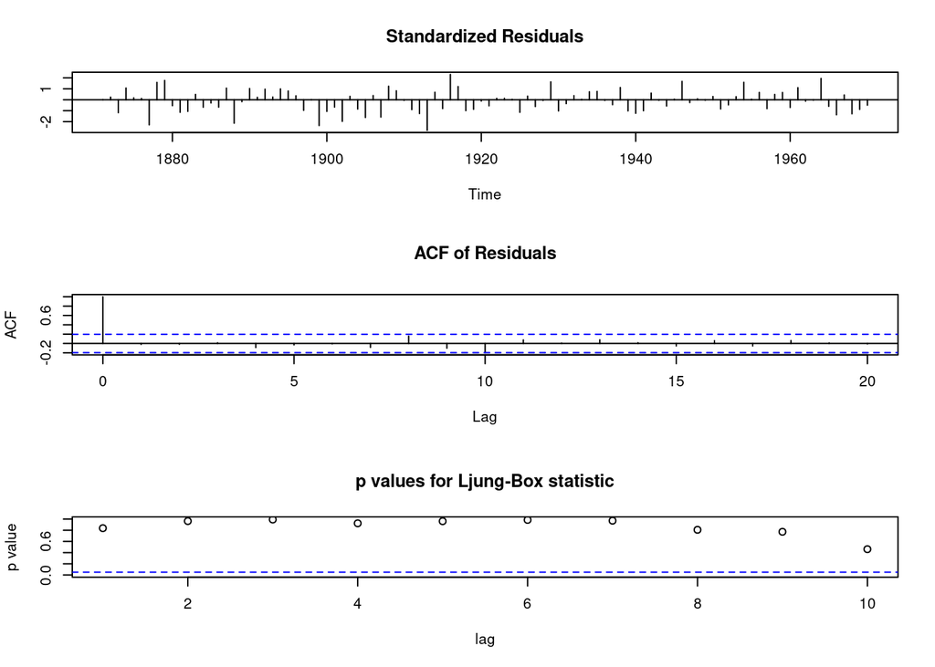

Fig. 7

```r
tsdiag(fit211)
```

```r
fit011 = arima(nile, order = c(0,1,1))
fit011
```

```
##
## Call:
## arima(x = nile, order = c(0, 1, 1))
##
## Coefficients:
##           ma1
##       -0.7329
## s.e.   0.1143
##
## sigma^2 estimated as 20600:  log likelihood = -632.55,  aic = 1269.09
```

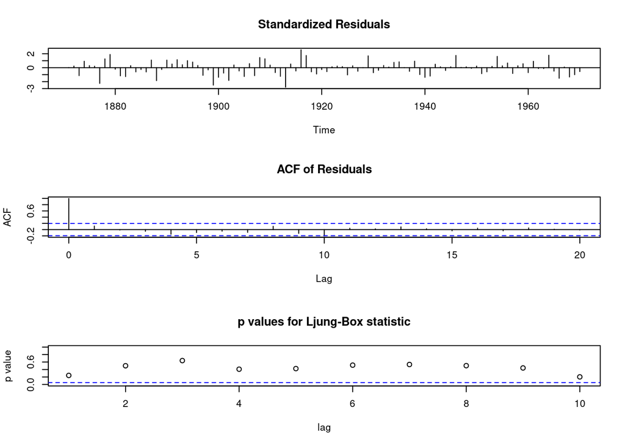

Fig. 8

```r
tsdiag(fit011)
```

After a look at the residuals, acf and the p values for Ljung-Box statistic, I see that the four models are a good fit. Now I will do a further analysis using the aic of the models and the standard errors of the coefficients.

```r
fit101$call$order
```

```
## c(1, 0, 1)
```

```r
paste("aic: ", fit101$aic)
```

```
## [1] "aic:  1282.07757841271"
```

```r
fit101$coef/sqrt(diag(fit101$var.coef))
```

```
##       ar1       ma1 intercept
##  8.072857 -2.713200 19.723292
```

```r
fit111$call$order
```

```
## c(1, 1, 1)
```

```r
paste("aic: ", fit111$aic)
```

```
## [1] "aic:  1267.25476355204"
```

```r
fit111$coef/sqrt(diag(fit111$var.coef))
```

```
##        ar1        ma1
##   2.130484 -14.452883
```

```r
fit211$call$order
```

```
## c(2, 1, 1)
```

```r
paste("aic: ", fit211$aic)
```

```
## [1] "aic:  1268.89612516533"
```

```r
fit211$coef/sqrt(diag(fit211$var.coef))
```

```
##         ar1         ar2         ma1
##   2.2048315   0.5979482 -15.0915605
```

```r
fit011$call$order
```

```
## c(0, 1, 1)
```

```r
paste("aic: ", fit011$aic)
```

```
## [1] "aic:  1269.09124876638"
```

```r
fit011$coef/sqrt(diag(fit011$var.coef))
```

```
##       ma1
## -6.411303
```

## Conclusions

An ARIMA model has been presented, The model consists of two learned parameters, the auto-regressive ($\phi$), the Moving average ($\theta$), and a regular difference. No evidence of seasonality was learned from the figures as the information provided was by year. The autocorrelation function and the partial autocorrelation function were used to identify and verify the assumptions of the model, however, I also used the relation coefficient standard error and Akaike Information Criterion.